# HW 9: Hyptothesis testing (2)

Due: Friday, January 17 by 11:59 CET

# Homework 9: Hypothesis Testing (Part 2)

# Exercise 1: Comparing two groups with a $t$-test (20 points)

```r
group_1 <- c(
  104, 105, 100, 91, 105, 118, 164, 168, 111, 107, 136, 149, 104, 114, 107, 95,
  83, 114, 171, 176, 117, 107, 108, 107, 119, 126, 105, 119, 107, 131
)
group_2 <- c(
  133, 115, 84, 79, 127, 103, 109, 128, 127, 107, 94, 95, 90, 118, 124, 108,
  87, 111, 96, 89, 106, 121, 99, 86, 115, 136, 114
)
```

# Exercise 2: Pearson’s $\chi^2$-test of independence (20 pointss)

Here’s a table of counts showing the results from an (imaginary) enquete asking students for the program in which they are enrolled and their favorite statistical paradigm. Use a $\chi^2$-test using function `chisq.test` to check if there is a basis for the assumption that preferences of statistical method differ between different fields of study.

```r
observed_counts <- matrix(
  c(
    31,56,23,
    104,67,12,
    24,34,42,
    19,16,8
  ),
  nrow = 4,
  byrow = T,
  dimnames = list(
    program = c("CogSci", "Psych", "Computer Science", "Philosophy"),
    preference = c("frequentist", "Bayes", "bootstrap")

  )
)
```

# Exercise 3: Understanding a mystery function (8 points)

The point of this exercise is to practice a kind of task that may well occur in the written exam. [The secondary (cheeky) point of this exercise is to introduce a function that might just happen to be useful for some other thing.]

Consider this function and try to understand what it does.

```r
mysterious_function <- function(vec) {
  map_lgl(
    1:(length(vec)-1),
    function(i) {vec[i] == vec[i+1]}
  ) %>% sum()
}
```

Describe what this function does in plain and easy natural language. For example, your answer could be something like the following (but if it was this particular answer, it would be ridiculously off the mark):

> This function takes as input a vector of tibbles and returns the index of each tibble in the input vector which is longer than the tibble that occurs last in the input vector.

# Exercise 4: Simulating a $p$-value for a custom-made test statistic (30 points)

The point of this exercise is to make you understand better the notion of a test statistic and to become aware of the fact that *you* could just *invent* a test statistic to maximally address *your* specific problem or application. This exercise should also make you experience that it is possible to compute a $p$-value based on a test statistic for whose sampling distribution you cannot give a concise mathematical characterization (even if approximate).

## Binomial test of fairness (4 points)

We consider a binomial test of a coin’s fairness. We have observed $k = 15$ heads out of $N = 30$ flips. Use the function `binomial.test` to calculate a two-sided $p$-value for the null hypothesis that $\theta = 0.5$. Interpret the result.

## Questioning independence based on swaps (4 points)

The previous test addressed one aspect of our data: the number of heads in the $N = 30$ flips. Remember that we said in class that the number $k$ is a test statistic. It is a good one if what we want to get is information about $\theta$.

But there are many vectors of raw data with $N = 30$ that give us a value of test statistic $k = 15$. Here are three:

```r
obs_1 <- rep(c(1,0), each = 15)  # 15 ones followed by 15 zeros
obs_2 <- rep(c(1,0), times = 15) # 15 pairs of one-zero
obs_3 <- c(1,1,1,1,0,0,0,0,0,0,1,1,1,1,0,0,0,1,1,0,0,1,1,1,1,0,0,0,0,1)
```

We know that all of these observations will lead to the same outcome under a binomial test. But there is another feature of these raw data vectors that should concern us, and that is whether each observation was truly independent of the previous. (Notice that independence of each coin flip of any other is a fundamental assumption (which might just be wrong!) of the binomial test.)

So, to address the independence issue, let’s just come up with our own (*ad hoc*) test statistic. Let’s just count the number of non-identical consecutive outcomes, i.e., the number of times that observation $i$ was different from observation $i+1$. Define a function called `number_of_swaps` that takes vectors like `obs_X` from above as input and returns the number of non-identical consecutive outcomes. Apply the function to the three vectors of observations above.

## Approximating a sampling distribution via sampling (8 points)

The number of swaps is a test statistic. (It is simple and useful, but no claim is made here regarding whether it is the best test statistic to address independence!) But what if we do not know a formula that characterizes its sampling distribution?

The answer is: sampling! If we do not know a mathematical characterization of a distribution, but we can write an algorithm of the data-generating process, we can work with (a large set of) samples. (That’s old news.) We can use samples to approximately calculate a $p$-value, too. (That’s news (of sorts).)

Write a function called `sample_nr_swaps` that takes as input an argument `n_samples`. The number `n_samples` is the number of samples the function returns. So, for `n_samples = 100`, this function returns 100 samples. A single sample is the number of swaps in a randomly generated vector of 30 random samples from 1 and 0 (each equally likely). [Hint: to generate a single vector of the kind we are after, you can use this code snippet: `sample(c(1,0), size = 30, replace = T)`. So, you would be executing this code snippet `n_sample` times, so you would be generating `n_samples` 30-place random vectors.]

## Plot the sampling distribution (6 points)

Using the previously defined function `sample_nr_swaps`, get 100,000 samples of swaps, obtain counts for each number of swaps, and plot the result using `geom_col`. This could look as follows:

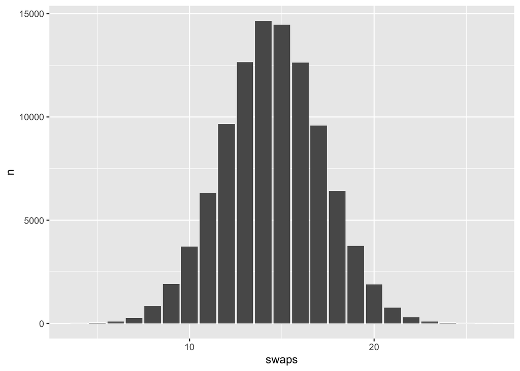

## Compute a $p$-value with MC-sampling (8 points)

Consider the vector $obs_3$ above. It’s number of swaps is surprisingly low under our assumption of independence of flips. We want to approximate a one-sided $p$-value using MC-samplinig. Fill in the missing bits-and-pieces in the code below, compute a $p$-value and interpret the result.

```r
n_samples <- 100000
MC_sampling_p_value <- function(n_samples) {
  %FILL-ME%(sample_no_swaps(n_samples) %FILL-ME% number_of_swaps(%FILL-ME%))
}
MC_sampling_p_value(n_samples)
```